# Question

In symbolic logic, we often use the following symbols for [NOT](https://en.wikipedia.org/wiki/Negation), [AND](https://en.wikipedia.org/wiki/Logical_conjunction), and [OR](https://en.wikipedia.org/wiki/Logical_disjunction):

$$\neg ~=~ \text{not}$$
$$\cap ~=~ \text{and} ~=~
\text{intersection}$$
$$\cup ~=~
\text{or} ~=~ \text{union}$$

In this case (and almost always), [unary operators](https://en.wikipedia.org/wiki/Unary_operation) (like $\neg$) have higher [precedence](https://en.wikipedia.org/wiki/Order_of_operations) than [binary operators](https://en.wikipedia.org/wiki/Arity) (like $\cup$ and $\cap$).

You are given the following probabilities (regarding events $A$ and $B$).

- $P(A\cap \neg B)=0.36$
- $P(A)=0.53$
- $P(A\cup B)=0.76$

Calculate the following:

- $P(A\cap B)=$ ##ANSWER1## students
- $P(\neg A\cap B)=$ ##ANSWER2## students
- $P(\neg A\cap \neg B)=$ ##ANSWER3## students
- $P(\neg A)$ ##ANSWER4## students
- $P(B)=$ ##ANSWER5## students
- $P(\neg B)$ ##ANSWER6## students

## Optional metaphorical context

Imagine getting blindfolded and throwing darts at a board far away on a gusty day. On that board are two overlapping circles: circle A and circle B. If you miss the board completely, the throw does not count, and you try again. If you hit circle A, that counts as event $A$. If you miss circle A (but hit the board), that counts as $\neg A$. The probability that you hit circle A will depend on the proportion of the board’s area taken up by circle A.

$$P(A) ~=~ \frac{\text{area of circle
A}}{\text{area of board}}$$
$$P(\neg
A) ~=~ \frac{\text{area of board} ~~-~~ \text{area of circle
A}}{\text{area of board}}$$

## Answerlist

- 0.15
- 0.17
- 0.19
- 0.21
- 0.23
- 0.17
- 0.19
- 0.21
- 0.23
- 0.25
- 0.16
- 0.18
- 0.20
- 0.22
- 0.24
- 0.47
- 0.49
- 0.51
- 0.53
- 0.55
- 0.38
- 0.40
- 0.42
- 0.44
- 0.46
- 0.54
- 0.56
- 0.58
- 0.60
- 0.62

# Solution

- $P(A\cap B)=0.17$
- $P(\neg A\cap B)=0.23$
- $P(\neg A \cap \neg B)=0.24$
- $P(\neg A)=0.47$
- $P(B)=0.4$
- $P(\neg B)=0.6$

You might find it helpful to draw a Venn diagram.

- NOTE: These areas are not drawn to scale.

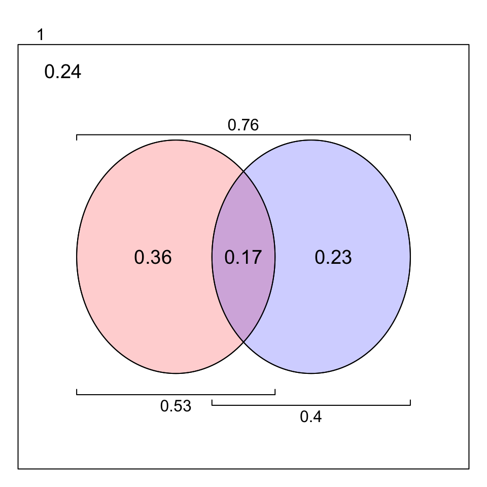

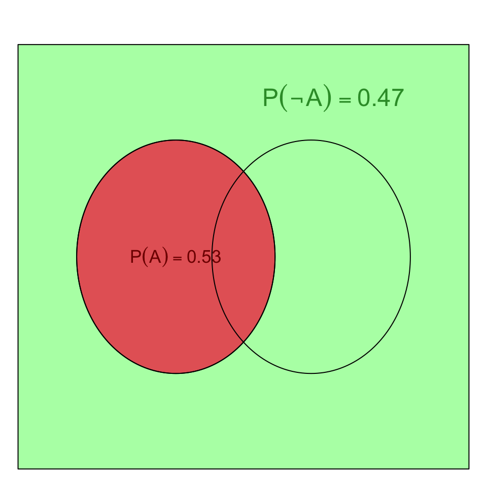

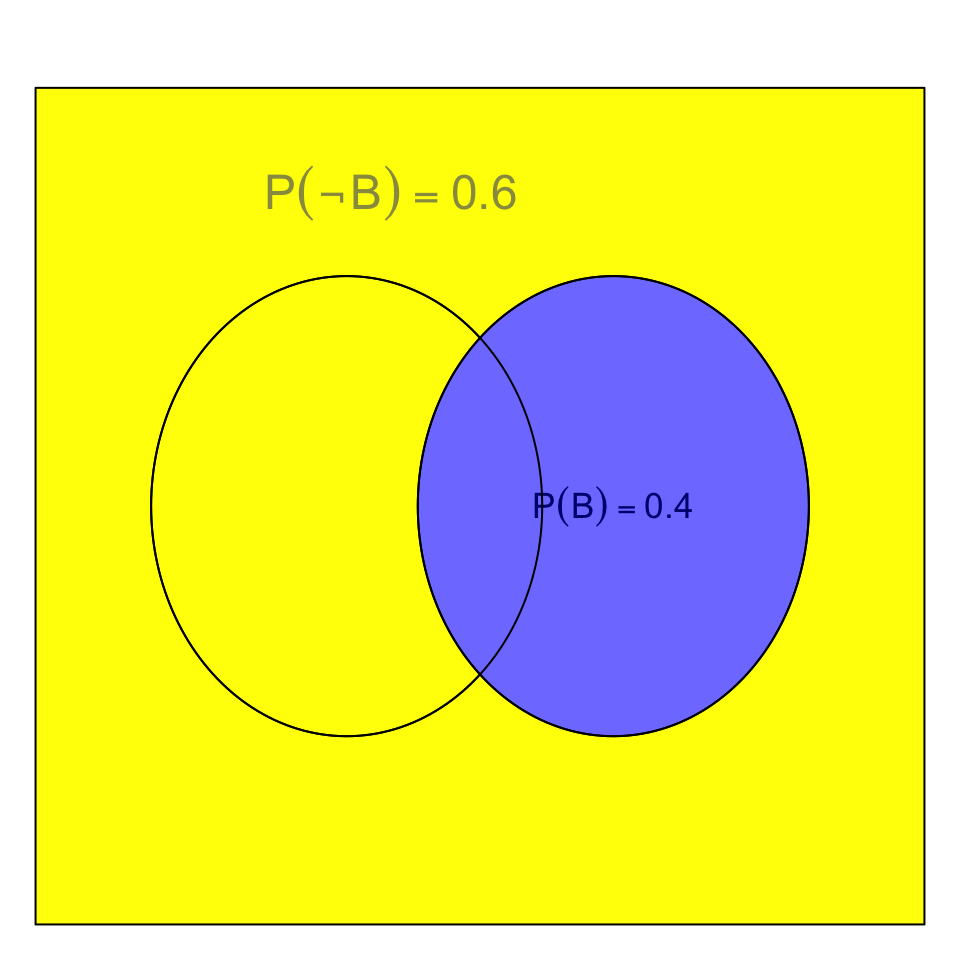

# Meta-information

extype: cloze exclozetype: schoice|schoice|schoice|schoice|schoice|schoice exsolution: 01000|00010|00001|10000|01000|00010 exname: probs